# Week 7: Affiliation Networks

## Affiliation Networks

How do social actors or entities “hang” together?

-Direct ties: Social relations

-Indirect ties: Membership

```
- What does it mean to be affiliated through a literal group, activity,
or event?
```

“A man may regarded as the point of intersection of an indefinite number of circles representing social groups, having as many arcs passing through him as there are groups.” (Cooley)

What does it mean to be connected through a generic group or an abstraction?

## Duality: Breiger (1974)

Argument

Metaphor: People intersect through their associations, which defines (in part) their individuality.

Duality: Relations among groups implies relations among individuals or vice versa.

## Affiliation Example

Let’s begin with a person-to-group matrix

Each column is a group, each cell is a person, and the cell=1 if the person in that row belongs to the group in that column. You can calculate how many groups shared between two individuals by comparing the rows. Identify every column where both rows equals 1 and sum them. This is the overlap.

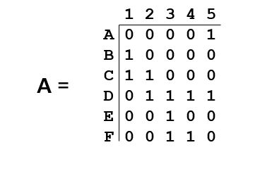

You can also tell the total number of group members by summing the columns and the total number of groups/indvidual by summing the rows.

## Let’s make a matrix in R

```r
one <- c(0, 1, 1, 0, 0, 0)
two <- c(0, 0, 1, 1, 0, 0)
three <- c(0, 0, 0, 1, 1, 1)
four <- c(0, 0, 0, 1, 0, 1)
five <- c(1, 0, 0, 1, 0, 0)

dual <- cbind(one, two, three, four, five)

rownames(dual) <- c("A", "B", "C", "D", "E", "F")

print(dual)
```

```
##   one two three four five
## A   0   0     0    0    1
## B   1   0     0    0    0
## C   1   1     0    0    0
## D   0   1     1    1    1
## E   0   0     1    0    0
## F   0   0     1    1    0
```

## Duality, Transformations, Matrix Algebra

Recall that the matrix is a simple and elegant way to manipulate networks. That is most obviously the case, perhaps, when thinking through duality.

From persons-to-groups to persons *and* groups.

If we multiple our Persons-to-Group matrix by its transpose, we have a Person matrix.

If we multiply the traspose of our Persons-to-Group matrix by the matrix itself, we have the Groups matrix.

## Matrix Operations

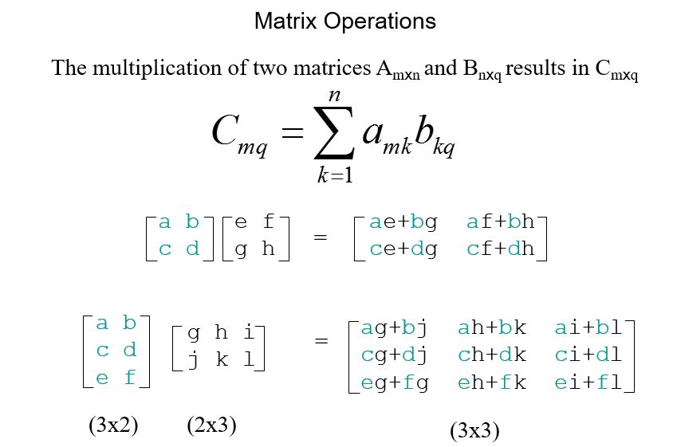

## Person Matrix in R

```r
person <- dual %*% t(dual)

print(person)
```

```
##   A B C D E F
## A 1 0 0 1 0 0
## B 0 1 1 0 0 0
## C 0 1 2 1 0 0
## D 1 0 1 4 1 2
## E 0 0 0 1 1 1
## F 0 0 0 2 1 2
```

## Group Matrix in R

```r
groups <- t(dual) %*% dual

print(groups)
```

```
##       one two three four five
## one     2   1     0    0    0
## two     1   2     1    1    1
## three   0   1     3    2    1
## four    0   1     2    2    1
## five    0   1     1    1    2
```

## Affiliation Networks Reprise

Breiger(1974:87): “With respect to the membership network…persons who are actors in one picture (the P matrix) are with equal legitimacy viewed as connections in the dual picture (the G matrix), and conversely for groups.”

The resulting network: - Is always symmetric - The diagonal tells you how many groups (persons) a person (group) belongs to (has).

## Bipartite Network

The general class of affiliation networks are known as *bipartite* or *two-mode* networks. The matrix transformation described above where we transform the network from two-mode to one-mode is called a *projection*.

One-mode projections, while perhaps more easy to understand, obviously involve a substantial loss of information.

While it remains more common, perhaps, to project two-mode networks, increasing work is looking at the tractability of keeping two-mode networks as two-modes.

## Igraph: Real Data Sketch

Let’s walk through the CEOs data from Wasserman and Faust (1994). CEOs share membership in groups.

bipartite.mapping(g) tells us if we are working with bipartite network.

```r
library(igraph)

ceo.bip <- read.graph("data/CEOS.net", format="pajek")

bipartite.mapping(ceo.bip)
```

```
## $res
## [1] TRUE
##
## $type
##  [1] FALSE FALSE FALSE FALSE FALSE FALSE FALSE FALSE FALSE FALSE FALSE FALSE
## [13] FALSE FALSE FALSE FALSE FALSE FALSE FALSE FALSE FALSE FALSE FALSE FALSE
## [25] FALSE FALSE  TRUE  TRUE  TRUE  TRUE  TRUE  TRUE  TRUE  TRUE  TRUE  TRUE
## [37]  TRUE  TRUE  TRUE  TRUE  TRUE
```

## CEO Plot 1

Let’s just plot it.

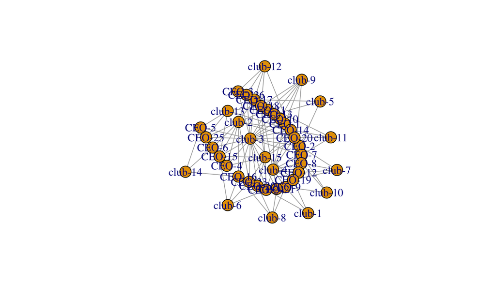

## CEO Plot 2: Distinguish Modes

That plot was not super informative as the modes are not defined. We can do better.

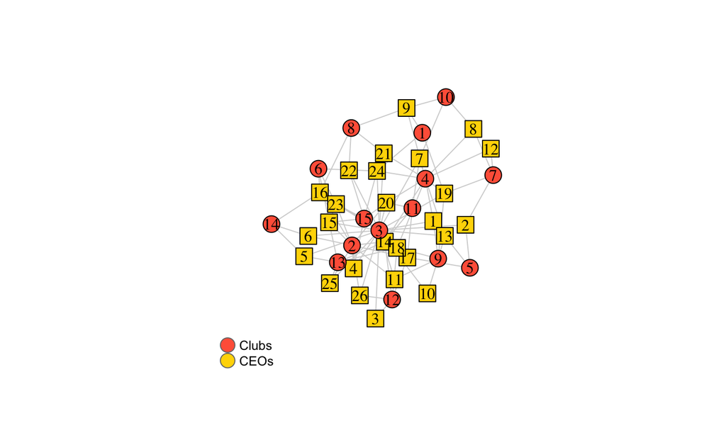

```r
V(ceo.bip)$color <- ifelse(V(ceo.bip)$type, "tomato", "gold")
V(ceo.bip)$shape <- ifelse(V(ceo.bip)$type, "circle", "square")
E(ceo.bip)$color <- "lightgray"

name <- V(ceo.bip)$name

name2 <- gsub(".*-","",name)

V(ceo.bip)$name <- name2

coords <- layout_with_fr(ceo.bip)

plot(ceo.bip, layout=coords, vertex.label.color = "black")
legend(x=-1.5, y=-1.1, c("Clubs","CEOs"), pch=21,
col="#777777", pt.bg=c("tomato", "gold"), pt.cex=2, cex=.8, bty="n", ncol=1)
```

## CEO Plot 2: Distinguish Modes

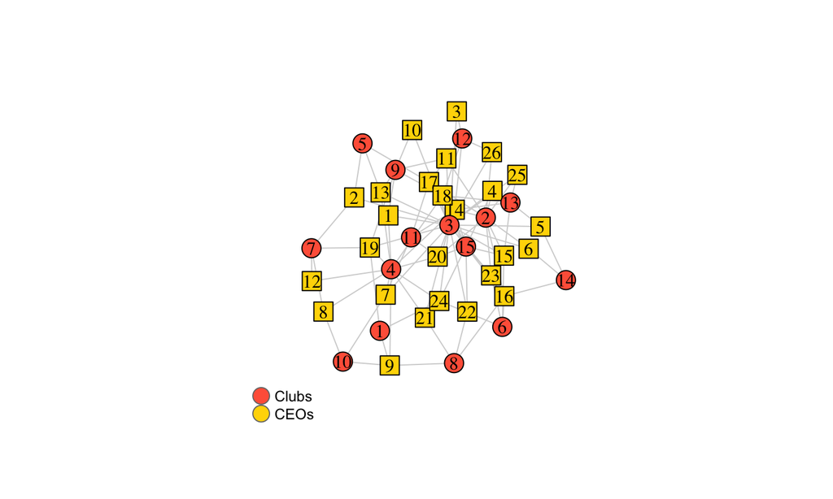

## CEO Plot 3: Bipartite Layout

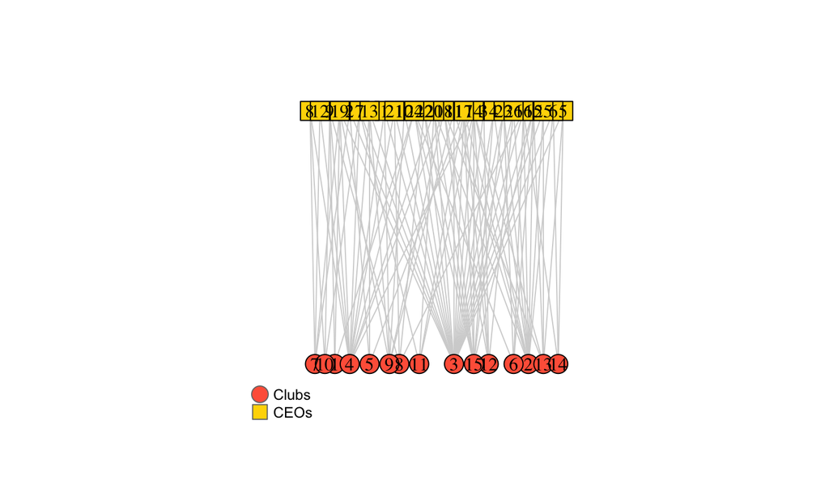

```r
coords <- layout_as_bipartite(ceo.bip)

plot(ceo.bip, layout=coords, vertex.label.color = "black")
legend(x=-1.5, y=-1.1, c("Clubs","CEOs"), pch=c(21,22),
       col="#777777", pt.bg=c("tomato", "gold"), pt.cex=2, cex=.8, bty="n", ncol=1)
```

## CEO Plot 3: Bipartite Layout

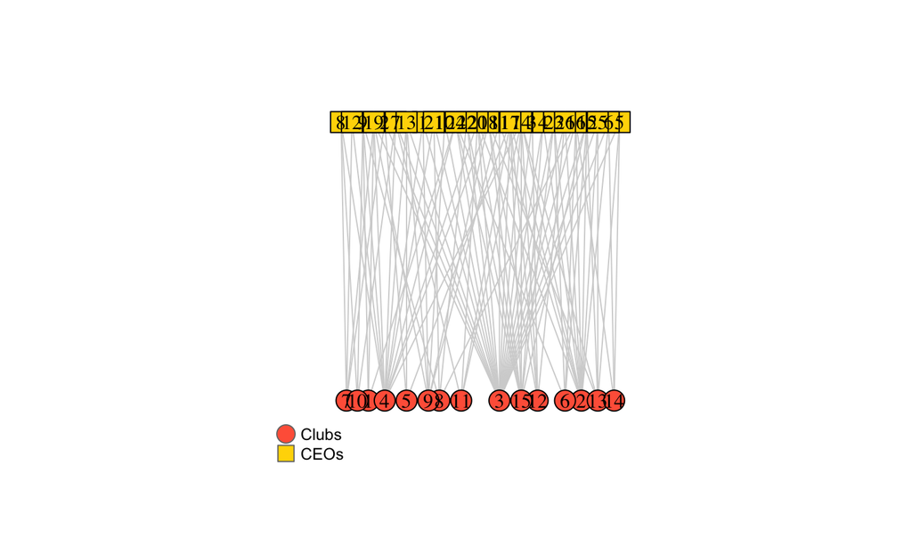

## Group Network: One-Mode

Easy way to project is to pull off matrix and then work through the transformation as described in the example network.

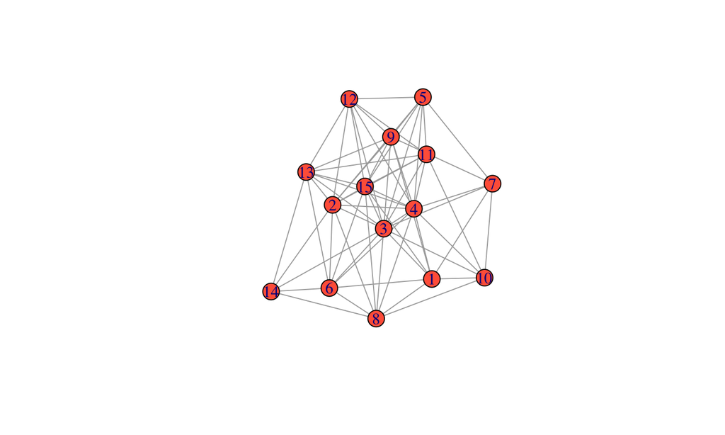

```r
ceo.mat <- as_incidence_matrix(ceo.bip)

clubs <-  t(ceo.mat) %*% ceo.mat

clubs.g <- as.undirected(simplify(graph_from_adjacency_matrix(clubs)))

plot(clubs.g, vertex.color="tomato")
```

## Group Network: One-Mode

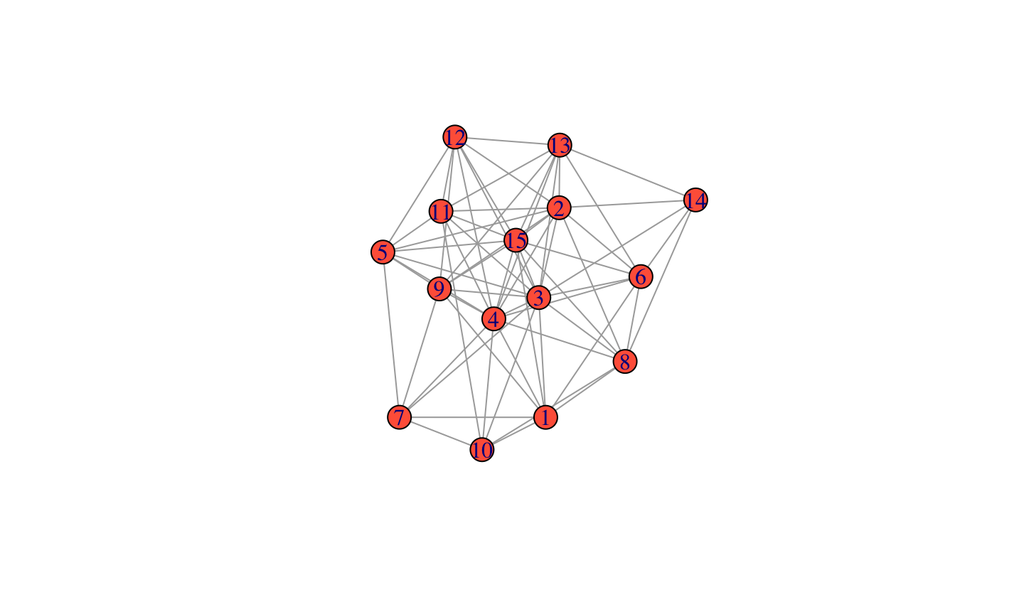

## Person Network: One-Mode

For the CEO network, we can just flip the matrix multiplication.

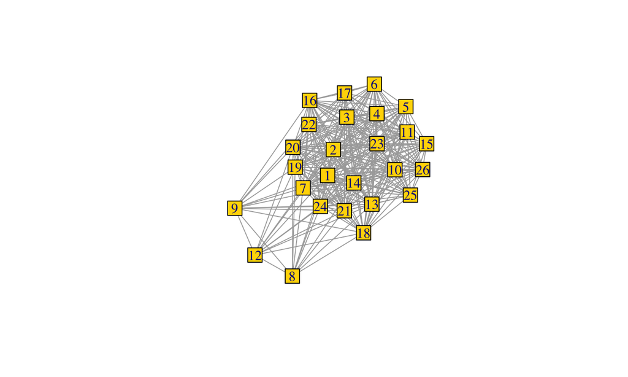

```r
ceos <-  ceo.mat %*% t(ceo.mat)

ceos.g <- as.undirected(simplify(graph_from_adjacency_matrix(ceos)))

plot(ceos.g, vertex.shape="square", vertex.color="gold")
```

## Person Network: One-Mode

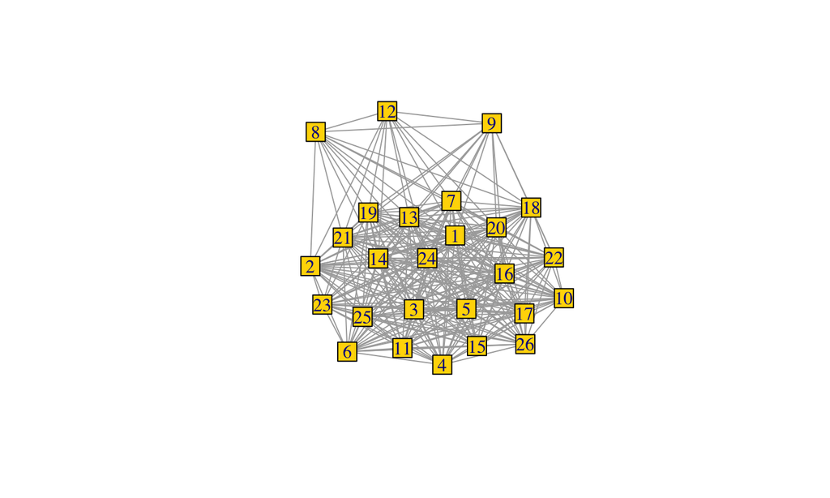

```r
ceos <-  ceo.mat %*% t(ceo.mat)

ceos.g <- as.undirected(simplify(graph_from_adjacency_matrix(ceos)))

plot(ceos.g, vertex.shape="square", vertex.color="gold")
```

## Text Networks

Text networks are increasingly common and relatively simple methods for document classification and/or generating thematic relationships across texts.

The goal is data reduction: Take a bunch of texts and simplify the relationship between them and/or their ideas.

Fundamentally, these are bipartite networks consisting of documents and words.

## Processing Texts

```
1. Find a collection of texts
2. Force the collection into a .csv (etc.)
3. Preprocess the text data
    - Remove stop words and or select POS (e.g. nouns)
    - N-grams?
    - Word length
    - Common words
4. Build document by word matrix
    - "Bag of words:" Word order doesn't matter
    - Weighted elements?: Common weight is tfidf
5. Project to terms or documents
6. Plot
```

## The textnets package

```r
comp <- read.csv("data/comp_socsci.csv")
```

## Clean Data

PrepText(text)

PrepTextNounPhrases(text)

Note the POS-tagger in PTNP takes some time to run.

```r
comp <- comp %>% filter(AB != "")

comp$text <- paste(comp$DE, comp$TI, comp$AB)

#english-lines

m_eng_lines   <- udpipe_download_model(language = "english-lines")
```

[output not shown]

[output not shown]

[output not shown]

[output not shown]

```r
m_eng_lines_path <- m_eng_lines$file_model
m_eng_lines_loaded <- udpipe_load_model(file=m_eng_lines_path)

text_annotated <- udpipe_annotate(m_eng_lines_loaded, x = comp$text) %>%
      as.data.frame() %>%
      select(-sentence)

nouns <- text_annotated %>% filter(upos=="NOUN")
```

## Clean Data

Get rid of short words, numbers, and words that appear fewer than 11 times.

```r
nouns$lemma <- tolower(nouns$lemma)

word_count <-as.data.frame(table(nouns$lemma))

word_count <- rename(word_count, lemma = Var1)

word_count$isnum <- nchar(gsub("[^0-9]+", "", word_count$lemma))

word_count <- word_count %>% filter(isnum==0)

word_count$lemma <- as.character(word_count$lemma)

word_count$wlength <- nchar(word_count$lemma)

word_count <- word_count %>% filter(wlength>3)

word_count <- word_count %>% filter(Freq>10)

word_count$keep <- 1

noun_fin <- left_join(nouns, word_count)
noun_fin[is.na(noun_fin)] = 0

noun_fin <- noun_fin %>% filter(keep==1)
```

## Build a network and viz

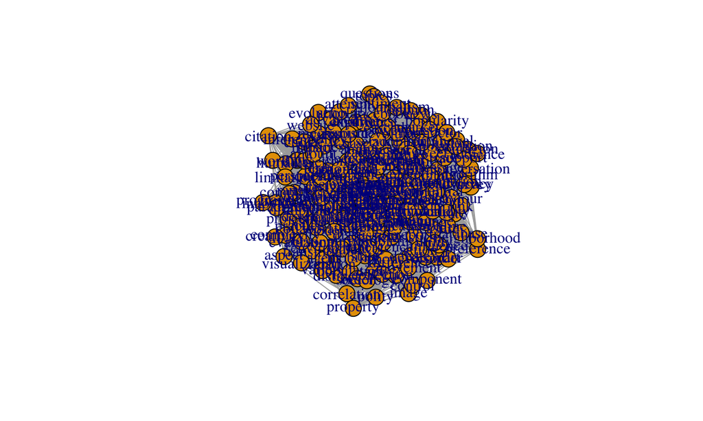

```r
noun_edge <- noun_fin %>% select(lemma, doc_id)

noun.g <- graph_from_data_frame(noun_edge)

V(noun.g)$type <- bipartite.mapping(noun.g)$type

n1mode.g <- bipartite_projection(noun.g, multiplicity = TRUE, which=FALSE)

V(n1mode.g)$wrd_cnt <- word_count$Freq

n1mode.g <- delete.vertices(n1mode.g, V(n1mode.g)[ degree(n1mode.g)==0 ])

plot(n1mode.g)
```

## Build a network and viz

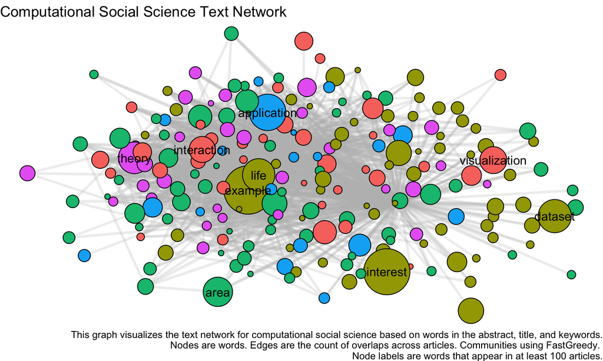